# Study Abroad and Covid Twitter Sentiment Analysis

3/11/2021

## Sentiment Analysis of Study Abroad and Covid

I analyzed Twitter data to gauge the sentiment surrounding studying abroad given worldwide travel restrictions due to the virus. Many universities are cautiously optimistic -BUT- there is unequal distribution of the vaccine worldwide and regional pockets of increased cases.

I was curious about the outlook of this activity in the Twittersphere.

For more details on the CDC’s guidance for IHE in relation to international travel or study abroad, visit: https://www.cdc.gov/coronavirus/2019-ncov/community/student-foreign-travel.html

## Tweets

I pulled Twitter data using the `rtweets` package to match variations of the search terms ‘study abroad and ’covid.’ This pulled 329 tweets. A special shout out to Jennifer Houchins @[toosweetgeek](https://twitter.com/TooSweetGeek) who helped me with the syntax of my search terms.

```
study_covid1 <-c("'study abroad' #covid OR covid",
                "'study abroad' #covid19 OR covid19",
                "#studyabroad #covid19 OR covid19",
                "#studyabroad #covid OR covid",
                '"study abroad" #covid19',
                "'study abroad' covid" ,
                "#studyabroad covid",
                "#studyabroad #covid19",
                "#studyabroad COVID-19",
                "'study abroad' COVID-19",
                "coronavirus #studyabroad",
                "coronavirus 'study abroad'",
                "#overseaseducation #covid19 OR covid19",
                "#Study_Abroad #covid19 OR covid19",
                "#intled #covid19 OR covid19")
```

## Sentiment Lexicons

For the sentiment analysis, I used both Vader and NRC to compare if the sentiment was overall positive or negative in regards to study abroad and covid-19.

1. **Vader**: [VADER: A Parsimonious Rule-based Model for Sentiment Analysis of Social Media Text](https://www.aaai.org/ocs/index.php/ICWSM/ICWSM14/paper/view/8109/8122)
2. **NRC**: [NRC Word-Emotion Association Lexicon](https://www.aaai.org/ocs/index.php/ICWSM/ICWSM14/paper/view/8109/8122)

## Vader

Like others mentioned, Vader is pretty great for sentiment analysis since you don’t need to tokenize text!

```
##Vader_df (vader call to evaluate a dataframe)
vader_abroad <-vader_df(studyabroad_vader$text)%>%
  select(text, compound, pos, neg, neu)
```

[figure not shown]

## Vader Results

The sentiment surrounding study abroad and covid using the Vader lexicon is overall positive but there is a good amount of negativity/neutrality in there as well.

| positive | negative | neutral |
| --- | --- | --- |
| 144 | 108 | 77 |

## Sample tweet by sentiment (positive)- Vader

> Do COVID Vaccines Help Restore Confidence in Study Abroad & International Travel? Travel SAFELY – VISIT Health Insurance Covers COVID Worldwide! Review BROCHUREs, Watch VIDEOs, Enroll ONLINE! https://t.co/tRE5qM54HW via [@constantcontact](https://twitter.com/ConstantContact?ref_src=twsrc%5Etfw) [pic.twitter.com/03WZU2jKbn](https://t.co/03WZU2jKbn)

> — VISIT Insurance (@VISIT_Insurance) [March 5, 2021](https://twitter.com/VISIT_Insurance/status/1367669706174455808?ref_src=twsrc%5Etfw)

## Sample tweet by sentiment (negative) - Vader

> well... my study abroad trip got cancelled. i’m not going to london anymore. Fuck this covid shit I swear

> — lyric!! (리릭)♡ ⁷ (@bertholdts) [March 4, 2021](https://twitter.com/bertholdts/status/1367483846044876807?ref_src=twsrc%5Etfw)

## NRC Lexicon

Results from the NRC Lexicon were very similar to those from Vader.

| positive | anger | anticipation | disgust | fear | joy | negative | sadness | surprise | trust |
| --- | --- | --- | --- | --- | --- | --- | --- | --- | --- |
| 541 | 71 | 157 | 24 | 184 | 51 | 230 | 161 | 41 | 145 |

## Vader versus NRC Sentiment results

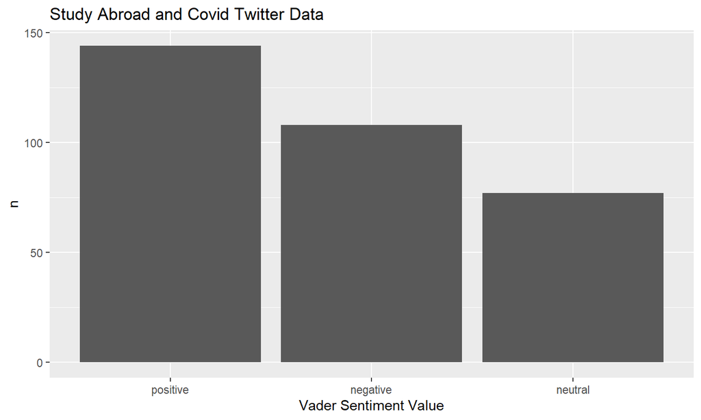

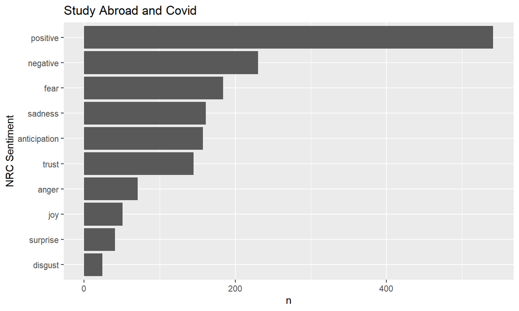

## Limitations

- The twitter developer app only pulls the last 6-9 days worth of data - would be nice to take a longer view
- Not as many university students post to Twitter as opposed to other platforms
- Institutions may or may not put their views out there on the subject
- Overall, it’s a small snapshot of the opinions surrounding a multi-faceted issue

## Conclusion

The data shows a limited snapshot of the sentiment around study abroad and covid but it seems to lean positive with some cautious apprehension mixed in. Hopefully domestic and international travel slowly resumes so that this sector can get back to their new normal.

[figure not shown]